# Druckkorrektur im offenen Bohrloch

Test an der Doppelkette GRIP (IMEI 301434062008130): Luftkette gegen Schneekette als Referenz

Author

Thom Laepple

Published

October 1, 2026

Die Temperaturschwankungen in luftgefüllten Bohrlöchern folgen der Druckänderung, `T′(z,t) = b(z)·F(t)` mit `F ≈ dp/dt` (`../KohnenRecords_Analyse/b40_druckschwankungen.qmd`). Die Doppelkette erlaubt, die daraus abgeleitete Korrektur unabhängig zu prüfen: Kette 1 hängt im offenen Loch, Kette 2 im 10 m entfernten verfüllten Loch, mit denselben Tiefen. Die Schneekette misst den Firn und dient als Referenz.

```r
source("decode_core.R")
library(dplyr); library(tidyr); library(ggplot2)
BLUE <- "#2a78d6"; ORANGE <- "#eb6834"; GREY <- "grey60"
th <- theme_bw(base_size = 12) + theme(panel.grid.minor = element_blank())

BIN <- setdiff(Sys.glob("../testdata/301434062008130-*.bin"), "../testdata/301434062008130-138.bin")
FIELDS <- c("ntc1", "ntc2", "gnd", "pressure"); N_NODES <- 20L
lab_cal <- load_lab_cal(NA_character_, N_NODES)
depth_map <- rbind(
  data.frame(position = 1:10,  chain = "Luft",   depth_m = c(1,3,5,8,10,13,16,21,26,30)),
  data.frame(position = 11:20, chain = "Schnee", depth_m = c(1,3,5,8,10,13,16,21,26,30)))
s <- bind_rows(lapply(BIN, function(f) {
  b <- read_snowchain_bin(f, FIELDS, N_NODES); nd <- bin_to_nodes(b, FIELDS, lab_cal); nd$position <- nd$node
  merge(nd, depth_map, by = "position") |> mutate(time = unix2utc(b$time_unix)) })) |>
  mutate(T = rowMeans(cbind(ntc1_C, ntc2_C), na.rm = TRUE)) |>
  distinct(time, chain, depth_m, .keep_all = TRUE)

# Auswertefenster: letzte 45 Tage (wie druck_temperatur.qmd); davor klingt die Einbaustörung ab
WINDOW <- 45
tm <- sort(unique(s$time)); tm <- tm[tm >= max(tm) - WINDOW * 86400]
tn <- as.numeric(tm); td <- (tn - tn[1]) / 86400
ZS <- c(13, 16, 21, 26, 30)
mat <- function(ch) sapply(ZS, function(z) { x <- s |> filter(chain == ch, depth_m == z)
  x$T[match(tm, x$time)] * 1000 })
A <- mat("Luft"); S <- mat("Schnee"); colnames(A) <- colnames(S) <- ZS
p <- (s |> group_by(time) |> summarise(p = mean(pressure_hPa, na.rm = TRUE)))$p[match(tm, sort(unique(s$time)))]

# Summit-AWS, stündlich (GEUS)
aws <- tryCatch({ options(timeout = 120)
  a <- read.csv("https://thredds.geus.dk/thredds/fileServer/aws/l3sites/csv/hour/SUM_hour.csv")
  a$t <- as.numeric(as.POSIXct(a$time, tz = "UTC")); a[is.finite(a$p_u), c("t", "p_u")] },
  error = function(e) NULL)
stopifnot(!is.null(aws))
pa   <- function(x) approx(aws$t, aws$p_u, x)$y
dpdt <- (pa(tn + 3 * 3600) - pa(tn - 3 * 3600)) / 0.25          # hPa/Tag, ±3 h um die Messung

hpf <- function(v) { if (all(is.na(v))) return(v); dd <- data.frame(y = v, x = td)
  v - predict(loess(y ~ x, data = dd, span = 0.5), dd) }
RA <- apply(A, 2, hpf); RS <- apply(S, 2, hpf); rp <- hpf(p)
zv <- c("16", "21", "26", "30")
```

Ausgewertet werden 46 Tagesprofile (14.08.–28.09.2026, je 15:13 UTC). Temperatur ist das Mittel aus NTC1 und NTC2, beide Reihen und der Druck sind gleich hochpassgefiltert (loess-Residuum, span 0,5). Die Schneekette hat bei 13 m keinen Messwert.

## Die Referenz: Schneekette

```r
ref_tab <- bind_rows(lapply(c("16", "21", "26", "30"), function(z) {
  f <- summary(lm(RS[, z] ~ rp))
  data.frame(`Tiefe (m)` = as.numeric(z), `Streuung (mK)` = round(sd(RS[, z]), 3),
             `b (mK/hPa)` = round(f$coefficients[2, 1], 4), `R²` = round(f$r.squared, 2),
             `Rest (mK)` = round(sd(resid(f)), 3), check.names = FALSE) }))
knitr::kable(ref_tab, row.names = FALSE,
  caption = sprintf("Schneekette gegen den Kettendruck (in Phase), Druckstreuung %.1f hPa.", sd(rp)))
```

Schneekette gegen den Kettendruck (in Phase), Druckstreuung 3.6 hPa.

| Tiefe (m) | Streuung (mK) | b (mK/hPa) | R² | Rest (mK) |
| --- | --- | --- | --- | --- |
| 16 | 0.156 | 0.0423 | 0.93 | 0.040 |
| 21 | 0.119 | 0.0317 | 0.90 | 0.038 |
| 26 | 0.109 | 0.0286 | 0.87 | 0.039 |
| 30 | 0.091 | 0.0217 | 0.72 | 0.049 |

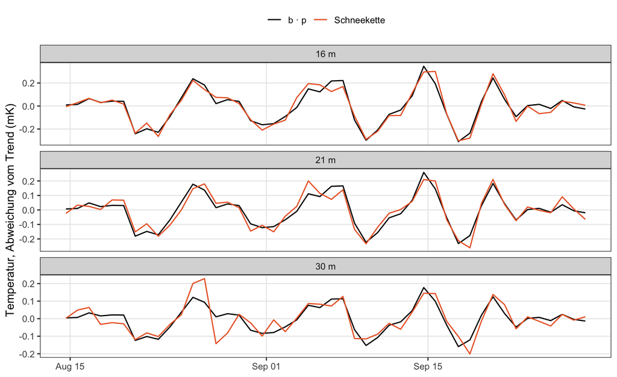

Figure 1

```r
sd_df <- bind_rows(lapply(c("16", "21", "30"), function(z) {
  b <- coef(lm(RS[, z] ~ rp))[2]
  data.frame(t = tm, z = paste(z, "m"), Schneekette = RS[, z], `b · p` = b * rp, check.names = FALSE) })) |>
  pivot_longer(-c(t, z)) |> mutate(z = factor(z, paste(c(16, 21, 30), "m")))
ggplot(sd_df, aes(t, value, colour = name)) + geom_line(linewidth = 0.6) +
  facet_wrap(~ z, ncol = 1, scales = "free_y") +
  scale_colour_manual(values = c(Schneekette = ORANGE, `b · p` = "black"), name = NULL) +
  labs(x = NULL, y = "Temperatur, Abweichung vom Trend (mK)") + th + theme(legend.position = "top")
```

Abbildung 1: Schneekette und Kompressionswärme `b·p` mit dem Druck der Kette. Die Skala ist Zehntel-mK; die Schneekette folgt dem Druck in Phase.

Die Schwankung im verfüllten Loch ist zu 72–93 % Kompressionswärme der Porenluft, in Phase mit p und mit `b = φ/(ρc)` wie in `druck_temperatur.qmd`. Nach deren Abzug bleiben 0,04–0,05 mK. Als Referenz für die Luftkette, deren Schwankungen 3–23 mK betragen, ist die Schneekette damit um zwei Größenordnungen genauer als nötig.

## Die Korrektur der Luftkette

Zwei Stufen, beide nur mit Daten aus dem offenen Loch und dem Druck:

- **b·dp/dt:** Regression je Tiefe auf die Druckänderung der Summit-AWS in den ±3 h um die Messung.
- **b·F:** zusätzlich der Rest, den dp/dt nicht erklärt, gemittelt über die übrigen Tiefen 13–30 m und je durch `b` geteilt (für jede Tiefe ohne diese Tiefe selbst). `F = dp/dt + Rest`.

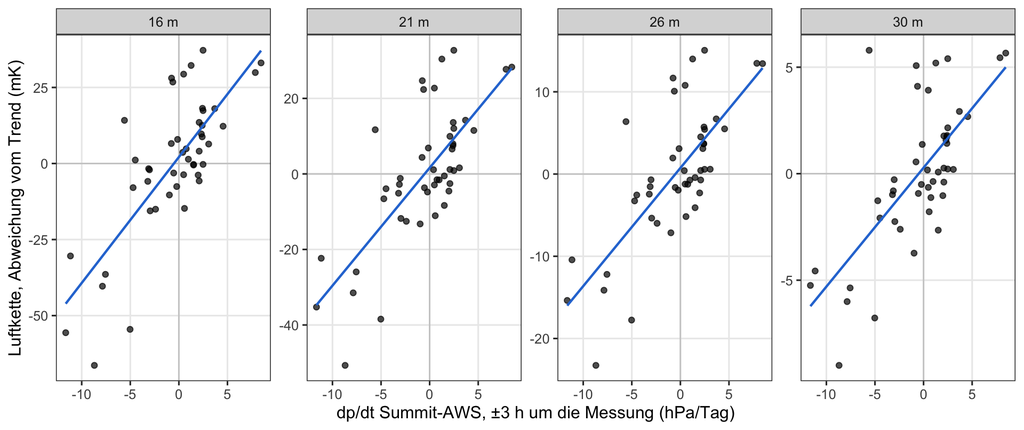

Figure 2

```r
sc <- bind_rows(lapply(zv, function(z) data.frame(z = factor(paste(z, "m"), paste(zv, "m")),
                                                  dpdt = dpdt, T = RA[, z])))
ggplot(sc, aes(dpdt, T)) + geom_hline(yintercept = 0, colour = "grey80") + geom_vline(xintercept = 0, colour = "grey80") +
  geom_point(size = 1.6, alpha = 0.7) + geom_smooth(method = "lm", se = FALSE, colour = BLUE, linewidth = 0.8) +
  facet_wrap(~ z, nrow = 1, scales = "free_y") +
  labs(x = "dp/dt Summit-AWS, ±3 h um die Messung (hPa/Tag)", y = "Luftkette, Abweichung vom Trend (mK)") + th
```

Abbildung 2: Unruhe der Luftkette gegen die Druckänderung um die Messzeit. Steigt der Druck, strömt wärmere Luft von oben nach (der Gradient im Loch ist negativ).

```r
b1 <- setNames(sapply(colnames(RA), function(z) unname(coef(lm(RA[, z] ~ dpdt))[2])), colnames(RA))
rr <- RA - outer(dpdt, b1)
korr <- sapply(colnames(RA), function(z) { k <- setdiff(colnames(RA), z)
  F <- dpdt + rowMeans(sweep(rr[, k, drop = FALSE], 2, b1[k], "/"))
  coef(lm(RA[, z] ~ F))[2] * F })
colnames(korr) <- colnames(RA)

tab <- data.frame(z = as.numeric(zv),
  r2   = sapply(zv, function(z) summary(lm(RA[, z] ~ dpdt))$r.squared),
  roh  = sapply(zv, function(z) sd(RA[, z] - RS[, z])),
  dpdt = sapply(zv, function(z) sd(RA[, z] - b1[z] * dpdt - RS[, z])),
  bF   = sapply(zv, function(z) sd(RA[, z] - korr[, z] - RS[, z])),
  ref  = sapply(zv, function(z) sd(RS[, z])))
knitr::kable(tab |> transmute(`Tiefe (m)` = z, `R² dp/dt` = round(r2, 2),
    `roh` = round(roh, 1), `nach b·dp/dt` = round(dpdt, 1), `nach b·F` = round(bF, 2),
    `Faktor` = round(roh / bF, 1), `Schneekette selbst` = round(ref, 2)), row.names = FALSE,
  caption = "Streuung der Differenz Luftkette − Schneekette (mK). Faktor: roh / nach b·F.")
```

Streuung der Differenz Luftkette − Schneekette (mK). Faktor: roh / nach b·F.

| Tiefe (m) | R² dp/dt | roh | nach b·dp/dt | nach b·F | Faktor | Schneekette selbst |
| --- | --- | --- | --- | --- | --- | --- |
| 16 | 0.59 | 23.2 | 14.9 | 4.14 | 5.6 | 0.16 |
| 21 | 0.55 | 18.0 | 12.0 | 1.84 | 9.8 | 0.12 |
| 26 | 0.55 | 8.3 | 5.6 | 0.87 | 9.6 | 0.11 |
| 30 | 0.48 | 3.5 | 2.5 | 0.80 | 4.4 | 0.09 |

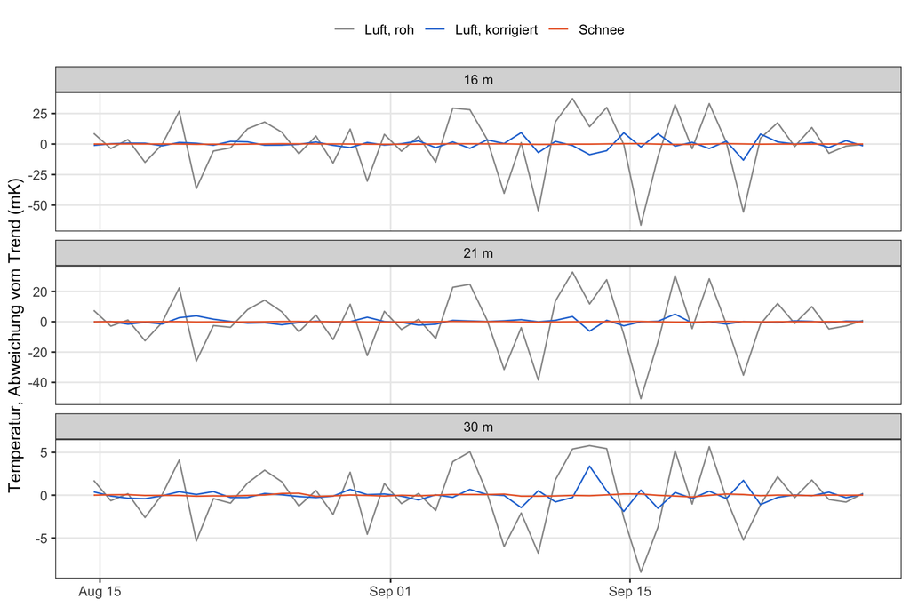

Figure 3

```r
fz <- c("16", "21", "30")
zd <- bind_rows(lapply(fz, function(z) data.frame(t = tm, z = paste(z, "m"),
  `Luft, roh` = RA[, z], `Luft, korrigiert` = RA[, z] - korr[, z], Schnee = RS[, z], check.names = FALSE))) |>
  pivot_longer(-c(t, z)) |>
  mutate(name = factor(name, c("Luft, roh", "Luft, korrigiert", "Schnee")),
         z = factor(z, paste(fz, "m")))
ggplot(zd, aes(t, value, colour = name)) + geom_line(linewidth = 0.5) +
  facet_wrap(~ z, ncol = 1, scales = "free_y") +
  scale_colour_manual(values = c(`Luft, roh` = GREY, `Luft, korrigiert` = BLUE, Schnee = ORANGE), name = NULL) +
  labs(x = NULL, y = "Temperatur, Abweichung vom Trend (mK)") + th + theme(legend.position = "top")
```

Abbildung 3: Hochpassgefilterte Temperatur in drei Tiefen. Die Schneekette (orange) schwankt um 0,1 mK und liegt auf dieser Skala auf der Nulllinie.

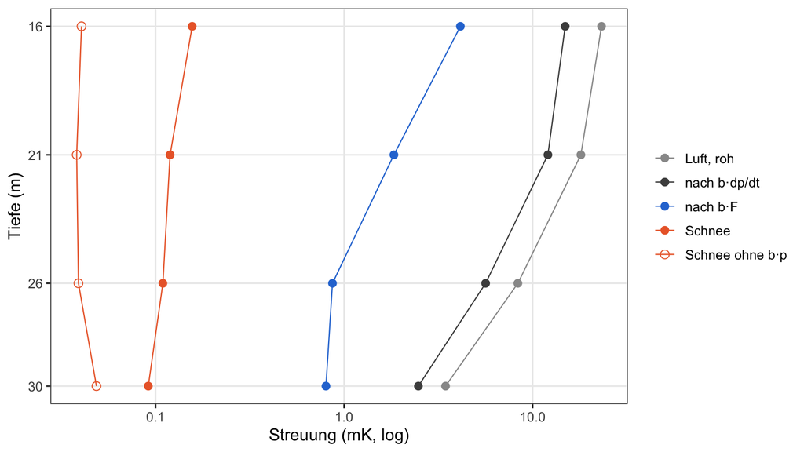

Figure 4

```r
pd <- tab |> transmute(z, `Luft, roh` = roh, `nach b·dp/dt` = dpdt, `nach b·F` = bF,
                       `Schnee` = ref,
                       `Schnee ohne b·p` = sapply(zv, function(zz) sd(resid(lm(RS[, zz] ~ rp))))) |>
  pivot_longer(-z) |>
  mutate(name = factor(name, c("Luft, roh", "nach b·dp/dt", "nach b·F", "Schnee", "Schnee ohne b·p")))
ggplot(pd, aes(value, z, colour = name, shape = name)) + geom_path(linewidth = 0.4) + geom_point(size = 2.6) +
  scale_x_log10() + scale_y_reverse(breaks = as.numeric(zv)) +
  scale_colour_manual(values = c(`Luft, roh` = GREY, `nach b·dp/dt` = "grey30", `nach b·F` = BLUE,
                                 Schnee = ORANGE, `Schnee ohne b·p` = ORANGE), name = NULL) +
  scale_shape_manual(values = c(16, 16, 16, 16, 1), name = NULL) +
  labs(x = "Streuung (mK, log)", y = "Tiefe (m)") + th
```

Abbildung 4: Fehler der Luftkette gegenüber der Schneekette vor und nach der Korrektur, dazu die Streuung der Schneekette selbst.

## Wie tief muss verfüllt werden?

Die Unruhe im offenen Loch fällt mit der Tiefe, weil der Gradient im Loch abnimmt und unterhalb des Close-off die Advektion entfällt. Für die Tiefen unter 30 m liefert B40 (head04, Kohnen, offenes 200-m-Loch, 180 Tagesprofile) das Profil, aus `../KohnenRecords_Analyse/pressure_correction.R`.

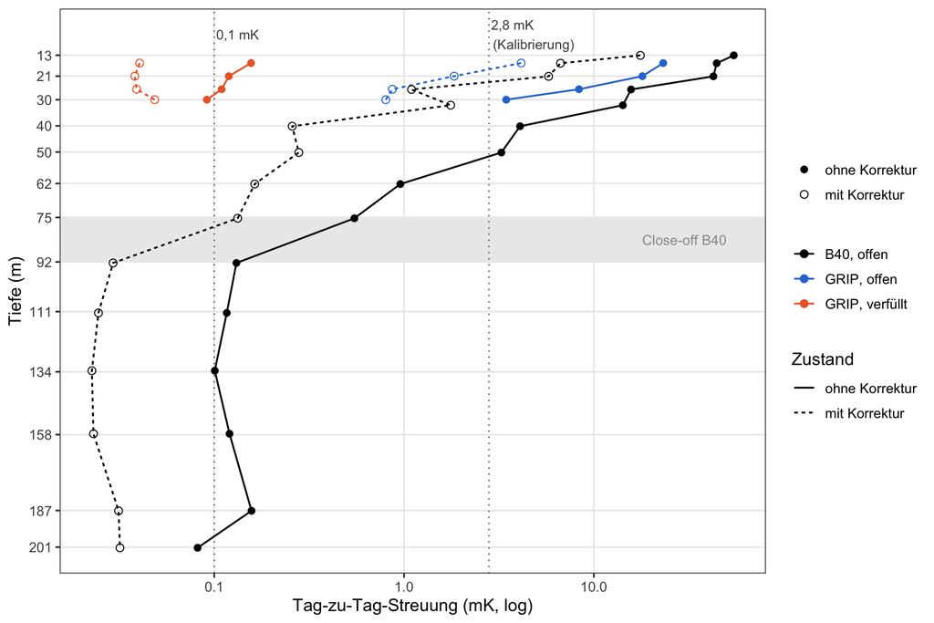

Figure 5

```r
b40 <- tryCatch(read.csv("../KohnenRecords_Analyse/data/pressure_correction_stats.csv"), error = function(e) NULL)
td_df <- bind_rows(
  data.frame(Standort = "GRIP, offen", z = tab$z, roh = tab$roh, korr = tab$bF),
  if (!is.null(b40)) b40 |> filter(grepl("head04", Kopf), z >= 13) |>
    transmute(Standort = "B40, offen", z, roh = sd_vor, korr = sd_nach),
  data.frame(Standort = "GRIP, verfüllt", z = tab$z, roh = tab$ref,
             korr = sapply(zv, function(zz) sd(resid(lm(RS[, zz] ~ rp)))))) |>
  pivot_longer(c(roh, korr), names_to = "Zustand") |>
  mutate(Zustand = factor(ifelse(Zustand == "roh", "ohne Korrektur", "mit Korrektur"),
                          c("ohne Korrektur", "mit Korrektur")))
ggplot(td_df, aes(value, z, colour = Standort, linetype = Zustand, shape = Zustand)) +
  annotate("rect", ymin = 75, ymax = 92, xmin = 0, xmax = Inf, fill = "grey92") +
  annotate("text", x = 30, y = 83.5, label = "Close-off B40", colour = GREY, size = 3.4) +
  geom_vline(xintercept = c(0.1, 2.8), colour = "grey50", linetype = "dotted") +
  annotate("text", x = c(0.1, 2.8), y = 5, label = c("0,1 mK", "2,8 mK\n(Kalibrierung)"),
           hjust = -0.05, size = 3.3, colour = "grey30") +
  geom_path(linewidth = 0.6) + geom_point(size = 2.2) +
  scale_x_log10() + scale_y_reverse(breaks = c(13, 21, 30, 40, 50, 62, 75, 92, 111, 134, 158, 187, 201), minor_breaks = NULL) +
  scale_colour_manual(values = c(`GRIP, offen` = BLUE, `B40, offen` = "black", `GRIP, verfüllt` = ORANGE), name = NULL) +
  scale_shape_manual(values = c(16, 1), name = NULL) +
  labs(x = "Tag-zu-Tag-Streuung (mK, log)", y = "Tiefe (m)") + th
```

Abbildung 5: Tag-zu-Tag-Streuung im offenen Loch (GRIP, B40) gegen die Tiefe, ohne und mit Korrektur `b·F`, dazu das verfüllte Loch in GRIP. Gepunktet: 0,1 mK und die relative Kalibrierung von 2,8 mK.

```r
if (!is.null(b40)) {
  t40 <- b40 |> filter(grepl("head04", Kopf), z >= 20) |>
    transmute(`Tiefe (m)` = round(z), `ohne Korrektur (mK)` = signif(sd_vor, 2), `mit Korrektur (mK)` = signif(sd_nach, 2))
  knitr::kable(t40, row.names = FALSE, caption = "B40, offenes Loch: Tag-zu-Tag-Streuung.")
}
```

B40, offenes Loch: Tag-zu-Tag-Streuung.

| Tiefe (m) | ohne Korrektur (mK) | mit Korrektur (mK) |
| --- | --- | --- |
| 21 | 43.000 | 5.800 |
| 26 | 16.000 | 1.100 |
| 32 | 14.000 | 1.800 |
| 40 | 4.100 | 0.260 |
| 50 | 3.300 | 0.280 |
| 62 | 0.960 | 0.160 |
| 75 | 0.550 | 0.130 |
| 92 | 0.130 | 0.029 |
| 111 | 0.120 | 0.025 |
| 134 | 0.100 | 0.023 |
| 158 | 0.120 | 0.023 |
| 187 | 0.160 | 0.031 |
| 201 | 0.082 | 0.032 |

- **Für 2,8 mK** (relative Kalibrierung) liegt das offene Loch in B40 ohne Korrektur erst ab ~60 m darunter (50 m: 3,3 mK, 62 m: 0,96 mK), mit Korrektur ab ~26 m (21 m: 5,8 mK, 26 m: 1,1 mK). Ohne Druckmessung wäre also bis **~60 m** zu verfüllen, mit Korrektur bis **~25 m**. In GRIP liegt die korrigierte Luftkette bei 26–30 m bei 0,8–0,9 mK.
- **Für 0,1 mK** (Niveau des verfüllten Lochs) reicht das offene Loch erst unterhalb des Close-off, mit und ohne Korrektur: bei 62–75 m sind es auch korrigiert noch 0,13–0,16 mK, ab 92 m 0,08–0,16 mK ohne und 0,02–0,03 mK mit Korrektur. Verfüllt werden müsste dafür **bis zum Close-off**, an Kohnen ~85–90 m.
- Die Werte gelten für ein Loch, das über die ganze Länge offen ist. Ob ein verfüllter oberer Abschnitt die Strömung darunter verringert, ist nicht gemessen; die Grenzen sind in diesem Sinn obere Schranken. Die Kompressionswärme unterhalb des Close-off (≤ 0,1 mK) hängt nicht von der Strömung ab und bleibt auch dann bestehen.
- Die Unruhe skaliert mit dem Temperaturgradienten im Loch. Er ist saisonal und standortabhängig; an einem Standort mit stärkerem Gradienten in 30–60 m verschieben sich die Grenzen nach unten.

## Monatsmittel: das Tiefenprofil mit und ohne Korrektur

Wie stark verschiebt die Korrektur das absolute Profil? Für B40 (Januar–Juli) werden je Monat die Mittel der Rohdaten und der korrigierten Reihe gebildet. Gezeigt ist die Abweichung vom mittleren korrigierten Profil des ganzen Zeitraums, damit Unterschiede im mK-Bereich sichtbar sind; die Fehlerbalken sind ±1 Standardfehler des Monatsmittels (AR(1)-korrigiert).

```r
old <- setwd("../KohnenRecords_Analyse")
b40ok <- tryCatch({ source("pressure_correction.R", local = TRUE); TRUE }, error = function(e) FALSE)
setwd(old)
if (b40ok) {
  mon4 <- format(h4$t[ok4], "%m")
  se_ar <- function(v) { v <- v[is.finite(v)]; n <- length(v); if (n < 5) return(NA)
    r1 <- cor(v[-1], v[-n]); r1 <- max(min(r1, 0.95), 0); sd(v) / sqrt(n * (1 - r1) / (1 + r1)) }
  ref4 <- colMeans(k4$y - k4$corr, na.rm = TRUE)
  mp <- bind_rows(lapply(seq_along(dep4), function(j) {
    raw <- k4$y[, j]; kor <- raw - k4$corr[, j]
    rr <- k4$r[, j]; rk <- rr - k4$corr[, j]
    bind_rows(lapply(sort(unique(mon4)), function(m) { i <- mon4 == m
      data.frame(z = dep4[j], Monat = m,
                 Version = c("roh", "korrigiert"),
                 T = c(mean(raw[i], na.rm = TRUE), mean(kor[i], na.rm = TRUE)) - ref4[j],
                 se = c(se_ar(rr[i]), se_ar(rk[i]))) })) })) |>
    filter(z >= 21) |>
    mutate(Version = factor(Version, c("roh", "korrigiert")),
           Bereich = factor(ifelse(z < 80, "21–75 m", "92–201 m"), c("21–75 m", "92–201 m")),
           Monat = factor(Monat, sprintf("%02d", 1:12), month.abb))
}
```

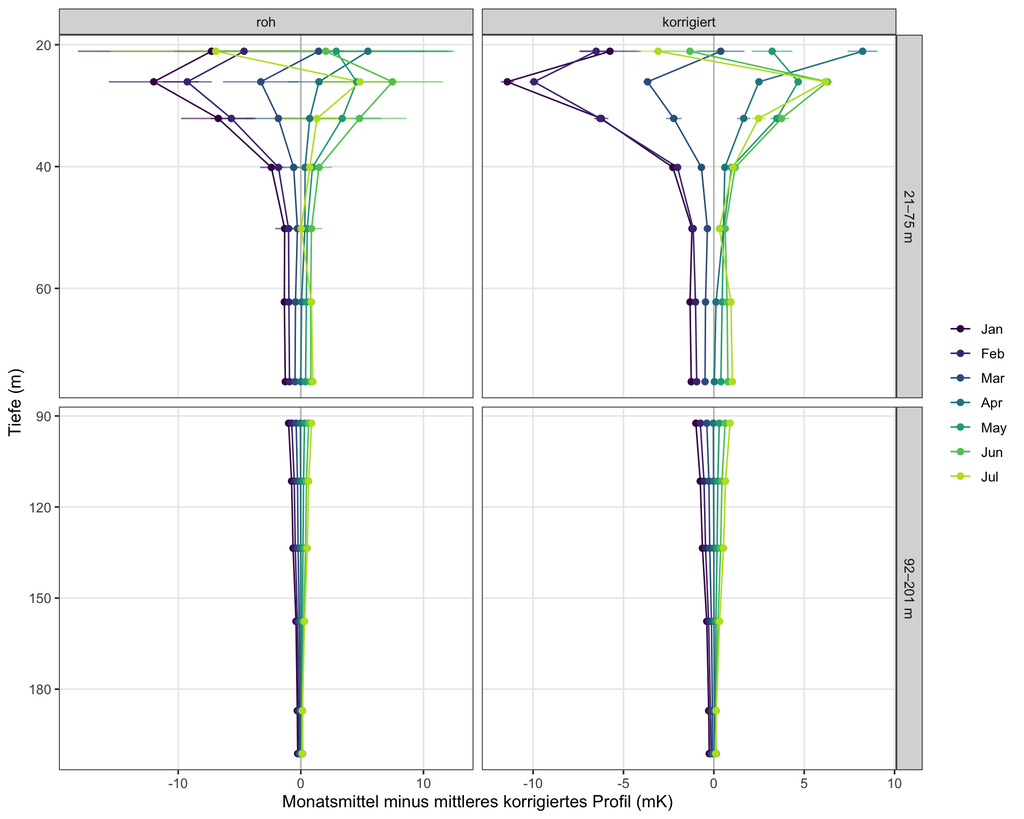

Figure 6

```r
if (b40ok) {
  ggplot(mp, aes(T, z, colour = Monat)) +
    geom_vline(xintercept = 0, colour = "grey75") +
    geom_errorbarh(aes(xmin = T - se, xmax = T + se), height = 0, alpha = 0.6) +
    geom_path(aes(group = Monat), linewidth = 0.5) + geom_point(size = 1.8) +
    facet_grid(Bereich ~ Version, scales = "free") + scale_y_reverse() +
    scale_colour_viridis_d(option = "D", end = 0.9, drop = TRUE, name = NULL) +
    labs(x = "Monatsmittel minus mittleres korrigiertes Profil (mK)", y = "Tiefe (m)") + th
}
```

```r
if (b40ok) {
  d4 <- mp |> select(z, Monat, Version, T, se) |>
    pivot_wider(names_from = Version, values_from = c(T, se)) |>
    group_by(z) |> summarise(`max |korr − roh| (mK)` = signif(max(abs(T_korrigiert - T_roh)), 2),
                             `SE roh (mK)` = signif(median(se_roh), 2),
                             `SE korrigiert (mK)` = signif(median(se_korrigiert), 2)) |>
    rename(`Tiefe (m)` = z) |> mutate(`Tiefe (m)` = round(`Tiefe (m)`))
  knitr::kable(d4, row.names = FALSE,
    caption = "B40: größte Verschiebung eines Monatsmittels durch die Korrektur und Median des Standardfehlers der Monatsmittel.")
}
```

B40: größte Verschiebung eines Monatsmittels durch die Korrektur und Median des Standardfehlers der Monatsmittel.

| Tiefe (m) | max \|korr − roh\| (mK) | SE roh (mK) | SE korrigiert (mK) |
| --- | --- | --- | --- |
| 21 | 3.9000 | 8.600 | 1.1000 |
| 26 | 1.3000 | 3.200 | 0.2300 |
| 32 | 1.2000 | 2.900 | 0.3900 |
| 40 | 0.3400 | 0.850 | 0.0590 |
| 50 | 0.2700 | 0.650 | 0.0580 |
| 62 | 0.0790 | 0.200 | 0.0350 |
| 75 | 0.0450 | 0.110 | 0.0300 |
| 92 | 0.0110 | 0.026 | 0.0063 |
| 111 | 0.0097 | 0.024 | 0.0047 |
| 134 | 0.0083 | 0.021 | 0.0045 |
| 158 | 0.0100 | 0.024 | 0.0044 |
| 187 | 0.0130 | 0.033 | 0.0064 |
| 201 | 0.0064 | 0.018 | 0.0056 |

- Die Korrektur verschiebt die Monatsmittel um höchstens 3,9 mK bei 21 m, 1,2–1,3 mK bei 26–32 m, 0,3 mK bei 40–50 m und ≤ 0,01 mK unterhalb des Close-off. Die Verschiebung ist `b` mal dem mittleren dp/dt des Monats und wechselt das Vorzeichen von Monat zu Monat.
- Sie bleibt in jedem Monat innerhalb des Standardfehlers der Rohdaten. Die Monatsmittel selbst werden durch die Korrektur nicht systematisch verfälscht; was sich ändert, ist ihre Unsicherheit (Tabelle).

Für GRIP liegen zwei Monate im Fenster. Die Sensoren der Doppelkette sind nicht einzeln kalibriert; sie laufen auf der universellen Mean-S4-Kurve mit einem Kalibrierrest von rund 37 mK RMS je Sensor (`druck_temperatur.qmd`). Die absoluten Profile der beiden Ketten unterscheiden sich um bis zu 110 mK, was in dieser Größenordnung liegt; die Korrektur ändert daran weniger als 1 mK. Vergleichbar ist deshalb die Änderung von August auf September, in der sich die Offsets herausheben. Ein Fehler in der Steigung der Kennlinie wirkt auf eine Änderung von wenigen mK nur anteilig (bei 1 % Steigungsfehler 0,05 mK).

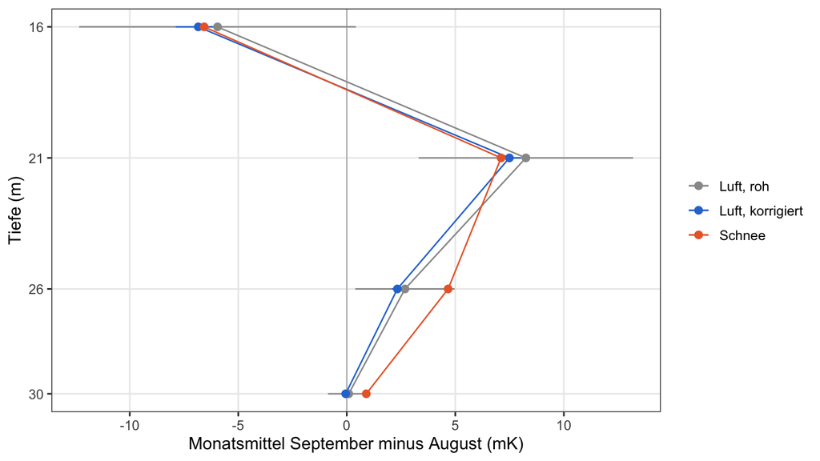

Figure 7

```r
mg <- format(tm, "%m"); i1 <- mg == "08"; i2 <- mg == "09"
dm <- function(v, r) c(mean(v[i2]) - mean(v[i1]), sqrt(var(r[i1]) / sum(i1) + var(r[i2]) / sum(i2)))
gp <- bind_rows(lapply(zv, function(z) {
  x <- rbind(dm(A[, z], RA[, z]), dm(A[, z] - korr[, z], RA[, z] - korr[, z]), dm(S[, z], RS[, z]))
  data.frame(z = as.numeric(z), Version = c("Luft, roh", "Luft, korrigiert", "Schnee"),
             d = x[, 1], se = x[, 2]) })) |>
  mutate(Version = factor(Version, c("Luft, roh", "Luft, korrigiert", "Schnee")))
ggplot(gp, aes(d, z, colour = Version)) +
  geom_vline(xintercept = 0, colour = "grey75") +
  geom_errorbarh(aes(xmin = d - se, xmax = d + se), height = 0) +
  geom_path(linewidth = 0.5) + geom_point(size = 2.2) +
  scale_y_reverse(breaks = as.numeric(zv)) +
  scale_colour_manual(values = c(`Luft, roh` = GREY, `Luft, korrigiert` = BLUE, Schnee = ORANGE), name = NULL) +
  labs(x = "Monatsmittel September minus August (mK)", y = "Tiefe (m)") + th
```

Abbildung 7: GRIP, Änderung des Monatsmittels von August (ab 14.08.) auf September in beiden Löchern, ±1 Standardfehler.

```r
knitr::kable(gp |> transmute(`Tiefe (m)` = z, Version, `Sep − Aug (mK)` = round(d, 2), `SE (mK)` = round(se, 2)) |>
  pivot_wider(names_from = Version, values_from = c(`Sep − Aug (mK)`, `SE (mK)`)), row.names = FALSE)
```

| Tiefe (m) | Sep − Aug (mK)_Luft, roh | Sep − Aug (mK)_Luft, korrigiert | Sep − Aug (mK)_Schnee | SE (mK)_Luft, roh | SE (mK)_Luft, korrigiert | SE (mK)_Schnee |
| --- | --- | --- | --- | --- | --- | --- |
| 16 | -5.95 | -6.84 | -6.57 | 6.38 | 1.04 | 0.05 |
| 21 | 8.25 | 7.49 | 7.11 | 4.94 | 0.53 | 0.03 |
| 26 | 2.68 | 2.33 | 4.67 | 2.29 | 0.25 | 0.03 |
| 30 | 0.09 | -0.05 | 0.90 | 0.96 | 0.20 | 0.03 |

## Beeinflusst der Druck das mittlere Profil?

In erster Ordnung nicht: Kompressionswärme und Verschiebung der Luft hängen linear vom Druck ab, der Druck schwankt um einen festen Mittelwert, beide mitteln sich heraus. Zwei Effekte zweiter Ordnung bleiben, beide hier für B40 abgeschätzt.

**Zusätzlicher Wärmetransport entlang des Lochs.** Die Luft pendelt und hält ihre Störung über τ. Das wirkt wie eine axiale Diffusivität `K_eff = ξ'²·⟨dp/dt·(p − Tiefpass_τ p)⟩`, mit der Verschiebung je hPa `ξ' = b/(−Γ·τ)`. Der Mittelwert stammt aus dem 95-s-Druck von B46. Die an die Wand abgegebene Wärme hängt an der Profilkrümmung `T''`; für eine Linienquelle im Firn (`k_f` = 0,6 W/(m·K)) ist die Verschiebung der Wandtemperatur `ΔT ≈ ρ_L c_L A K_eff T''/(2π k_f)·ln(L/a)`, mit L = 10 m.

**Abtastfehler im offenen Loch.** Der Sensor misst Luft aus z + ξ; im Zeitmittel liegt er um `½·⟨ξ²⟩·T''` neben der Wandtemperatur. `ξ_rms` folgt aus Tag-zu-Tag-Streuung / |Γ|.

```r
B46P <- "/Users/tlaepple/Nextcloud/KohnenRecords2526/2026_01_05/260105_B46/calibrated/CalibratedData_B46_2chains_260105.csv"
Q <- tryCatch({
  d46 <- read.csv(B46P); t46 <- as.numeric(as.POSIXct(d46$DateTime, tz = "UTC"))
  p46 <- rowMeans(as.matrix(d46[, grep("^N(79|80|81|82|83|84|85|86|88|89|90|91)_Pressure$", names(d46))])) / 1000
  lp <- p46[1]; h <- numeric(length(p46))
  for (i in seq_along(p46)) { if (i > 1) lp <- lp + (1 - exp(-(t46[i] - t46[i-1]) / 780)) * (p46[i] - lp); h[i] <- p46[i] - lp }
  ps <- as.numeric(stats::filter(p46, rep(1/5, 5), sides = 2))
  mean(c(NA, diff(ps) / diff(t46)) * h, na.rm = TRUE) }, error = function(e) 2.7e-6)
if (b40ok) {
  pr4 <- colMeans(k4$y - k4$corr, na.rm = TRUE) / 1000
  g4 <- splinefun(dep4, pr4, method = "natural")
  sel <- which(dep4 >= 20 & dep4 < 80)
  zo <- data.frame(z = round(dep4[sel]), b = k4$b[sel], G = g4(dep4[sel], 1) * 1000,
                   T2 = g4(dep4[sel], 2) * 1000, sdT = apply(k4$r[, sel], 2, sd, na.rm = TRUE)) |>
    mutate(xi = b / (-G * 780 / 86400), Keff = xi^2 * Q,
           C = 1000 * pi * 0.06^2 * Keff,
           dT_wand = C * T2 / 1000 / (2 * pi * 0.6) * log(10 / 0.06) * 1000,
           xi_rms = sdT / abs(G), dT_abtast = 0.5 * xi_rms^2 * T2) |>
    filter(abs(G) > 1)          # bei 75 m ist Γ ≈ 0, ξ dort nicht definiert
  knitr::kable(zo |> transmute(`Tiefe (m)` = z, `T'' (mK/m²)` = signif(T2, 2), `ξ' (m/hPa)` = signif(xi, 2),
      `K_eff (m²/s)` = signif(Keff, 2), `Wand-ΔT (mK)` = signif(dT_wand, 2),
      `ξ_rms (m)` = signif(xi_rms, 2), `Abtastfehler (mK)` = signif(dT_abtast, 2)), row.names = FALSE,
    caption = sprintf("B40, Effekte zweiter Ordnung auf das mittlere Profil. ⟨dp/dt·(p − Tiefpass_τ p)⟩ = %.1e hPa²/s (B46, drei Januartage).", Q))
}
```

B40, Effekte zweiter Ordnung auf das mittlere Profil. ⟨dp/dt·(p − Tiefpass_τ p)⟩ = 2.7e-06 hPa²/s (B46, drei Januartage).

| Tiefe (m) | T’’ (mK/m²) | ξ’ (m/hPa) | K_eff (m²/s) | Wand-ΔT (mK) | ξ_rms (m) | Abtastfehler (mK) |
| --- | --- | --- | --- | --- | --- | --- |
| 21 | 2.300 | 26.0 | 0.00190 | 0.06800 | 1.50 | 2.5000 |
| 26 | 1.700 | 15.0 | 0.00062 | 0.01700 | 0.85 | 0.6200 |
| 32 | 0.880 | 24.0 | 0.00150 | 0.02100 | 1.30 | 0.7800 |
| 40 | 0.300 | 12.0 | 0.00042 | 0.00190 | 0.69 | 0.0720 |
| 50 | -0.021 | 13.0 | 0.00045 | -0.00015 | 0.72 | -0.0056 |
| 62 | 0.350 | 6.7 | 0.00012 | 0.00065 | 0.38 | 0.0250 |

- Der axiale Transport durch die pumpende Luft ersetzt etwa die Leitung des beim Bohren entfernten Firns (Radius 3–11 cm), mehr nicht. Die Verschiebung der Wandtemperatur bleibt unter 0,1 mK; bei 5- bis 10-mal stärkerem Pumpen in Stürmen unter 1 mK.
- Der Abtastfehler `½⟨ξ²⟩T''` ist eine Verzerrung des Messwerts, kein Wärmeaustausch. Er beträgt bei 21 m 2,5 mK, bei 26–32 m 0,6–0,8 mK und fällt ab 40 m auf ≤ 0,07 mK und wird durch die lineare Korrektur `b·F` nicht entfernt. Sein Vorzeichen folgt `T''`.
- Unterhalb des Close-off gibt es keine Verschiebung; die Kompressionswärme mittelt sich heraus.
- Im verfüllten Loch gleicht sich die Porenluft in Millisekunden an das Eis an, und sie trägt 5·10⁻⁴ der Wärmekapazität; der Effekt auf das mittlere Profil liegt viele Größenordnungen unter µK. Windpumpen in den obersten 1–2 m ist ein anderer Mechanismus und hier nicht abgeschätzt.

## Ergebnis

- Die Druckänderung der Stunden um die Messung erklärt 48–59 % der Unruhe im offenen Loch (Abbildung 2).
- `b·dp/dt` allein verringert den Fehler um den Faktor 1,4–1,6, `b·F` um den Faktor 4–10. Es bleiben 4,1 / 1,8 / 0,85 / 0,80 mK bei 16 / 21 / 26 / 30 m.
- Das ist der Fehler der korrigierten Luftkette gegenüber dem Firn; die Referenz trägt 0,04–0,16 mK bei. Auch korrigiert ist die Luftkette 20- bis 100-mal ungenauer als das verfüllte Loch nach Abzug der Kompressionswärme.
- `b·F` setzt voraus, dass es in den Referenztiefen kein echtes, tiefenübergreifend gemeinsames Signal von Tag zu Tag gibt. Für 13–30 m ist das erfüllt; die Schneekette zeigt dort nach Abzug der Kompressionswärme nur 0,04–0,05 mK.
- **Verfülltiefe:** Für den Kalibrierfehler von 2,8 mK genügt Verfüllen bis ~60 m ohne Druckmessung oder bis ~25 m mit Korrektur. Für 0,1 mK ist bis zum Close-off zu verfüllen (Kohnen ~85–90 m); darunter liegt das offene Loch auch ohne Korrektur bei 0,08–0,16 mK.
- **Monatsmittel:** Die Korrektur verschiebt sie in B40 um höchstens 3,9 mK (21 m), bleibt immer innerhalb des Standardfehlers der Rohdaten und verkleinert diesen um den Faktor 3–14 (Abbildung 6). In GRIP gibt die korrigierte Luftkette die Monatsänderung der Schneekette bei 16–21 m innerhalb von 1 SE wieder (Abbildung 7).
- **Mittleres Profil:** Die Druckeffekte sind für die Bohrlochthermometrie Rauschen. Der zusätzliche Wärmetransport im offenen Loch verschiebt die Wandtemperatur um weniger als 0,1 mK; im offenen Loch bleibt ein Abtastfehler `½⟨ξ²⟩T''` im mK-Bereich oberhalb von ~35 m.